# CHURN_prueba_Data_Science2

```python
# Librerías
import pylab as pl
import scipy.optimize as opt
from sklearn import preprocessing
%matplotlib inline
import io

import pandas as pd
import numpy as np
import pickle
import matplotlib.pyplot as plt
import seaborn as sns
from sklearn.model_selection import train_test_split, GridSearchCV, validation_curve
from sklearn import metrics
from sklearn.metrics import (accuracy_score, roc_auc_score, confusion_matrix, roc_curve, auc,
                             mean_squared_error, log_loss, precision_recall_curve, classification_report,
                             precision_recall_fscore_support)
from sklearn.linear_model import LogisticRegression
from sklearn.naive_bayes import GaussianNB
from sklearn.svm import SVC, LinearSVC
from sklearn.tree import DecisionTreeClassifier, export_graphviz
#from sklearn.grid_search import GridSearchCV
from sklearn.ensemble import RandomForestClassifier, GradientBoostingClassifier, VotingClassifier
from xgboost.sklearn import XGBClassifier
#import scikitplot as skplt
#import lime
#import lime.lime_tabular
from sklearn.externals.six import StringIO
from IPython.display import Image
import pydotplus
import os

#Add Graphviz path to environment variable PATH, used for visualizing decision trees
os.environ["PATH"] += os.pathsep + 'C:/Program Files (x86)/Graphviz2.38/bin/'

#Import supporting functions
#from calculate_model_metrics import lift_plot_model, plot_roc, plot_grid_search, evaluate_model

import warnings
warnings.filterwarnings("ignore")
```

```python
# para cargar el archivo .csv guardado localmente

from google.colab import files
uploaded = files.upload()
```

Upload widget is only available when the cell has been executed in the current browser session. Please rerun this cell to enable.

```
Saving BASE3.xlsx to BASE3.xlsx
```

```python
pd.set_option('display.max_rows', 500)

churn_df = pd.read_excel('BASE3.xlsx')
churn_df
```

|  | REGIONAL | DEPARTAMENTO | TECNOL | GERENCIA | CANAL_HOMOLOGADO_MILLICON | tipo_fuerza_venta | estrato | antiguedad_meses | AÑOS | productos | portafolio | no_serv_tecnicos | fallo | asesoria_factura | pedidos_peticiones | reagendamiento | asesoria_servicios | retencion | Otras | quejas_fraude | traslado | Incumplimiento_pago | cliente_id |
| --- | --- | --- | --- | --- | --- | --- | --- | --- | --- | --- | --- | --- | --- | --- | --- | --- | --- | --- | --- | --- | --- | --- | --- |
| 0 | COSTA | MAGDALENA | HFC | CONTACT | SAC | INDIRECTA | 3 | 19.0 | 0-6 | TV+BA | Duo | 1.0 | No funciona línea telefónica | 0 | 0 | 0 | 0 | 0 | 0 | 0 | 0 | 0 | 1004369760 |
| 1 | COSTA | MAGDALENA | HFC | CONTACT | SAC | INDIRECTA | 3 | 19.0 | 0-6 | TV+BA | Duo | 1.0 | No funciona línea telefónica | 0 | 0 | 0 | 0 | 0 | 0 | 0 | 0 | 0 | 1004369760 |
| 2 | NOROCCIDENTE | ANTIOQUIA | HFC | CONTACT | SAC | INDIRECTA | 1 | 1.0 | 0-6 | TV | Individual | 1.0 | No navega | 0 | 0 | 0 | 0 | 0 | 0 | 0 | 0 | 0 | 1004371304 |
| 3 | COSTA | MAGDALENA | HFC | CONTACT | IN BOUND | INDIRECTA | 3 | 7.0 | 0-6 | TO+TV+BA | Trio | NaN | NaN | 0 | 0 | 0 | 0 | 0 | 0 | 0 | 0 | 1 | 1004382867 |
| 4 | COSTA | MAGDALENA | HFC | CONTACT | IN BOUND | INDIRECTA | 3 | 7.0 | 0-6 | TO+TV+BA | Trio | NaN | NaN | 0 | 0 | 0 | 0 | 0 | 0 | 0 | 0 | 1 | 1004382867 |
| ... | ... | ... | ... | ... | ... | ... | ... | ... | ... | ... | ... | ... | ... | ... | ... | ... | ... | ... | ... | ... | ... | ... | ... |
| 19937 | NOROCCIDENTE | ANTIOQUIA | REDCO | CONTACT | IN BOUND | INDIRECTA | 2 | NaN | 0-6 | TO+BA | Duo | NaN | NaN | 0 | 0 | 0 | 0 | 0 | 0 | 0 | 0 | 1 | 98589757 |
| 19938 | NOROCCIDENTE | ANTIOQUIA | REDCO | CONTACT | IN BOUND | INDIRECTA | 2 | NaN | 0-6 | TO+BA | Duo | NaN | NaN | 0 | 0 | 0 | 0 | 0 | 0 | 0 | 0 | 1 | 98589757 |
| 19939 | NOROCCIDENTE | ANTIOQUIA | REDCO | TIENDAS | TIENDAS | INDIRECTA | 2 | 89.0 | 0-6 | BA | Individual | 1.0 | Sin señal | 0 | 0 | 0 | 0 | 0 | 0 | 0 | 0 | 0 | 98590638 |
| 19940 | NOROCCIDENTE | ANTIOQUIA | HFC | CONTACT | SAC | INDIRECTA | 2 | 36.0 | 0-6 | TV | Individual | NaN | NaN | 0 | 1 | 0 | 0 | 0 | 0 | 0 | 0 | 0 | 98591843 |
| 19941 | NOROCCIDENTE | ANTIOQUIA | REDCO | CONTACT | OUT BOUND | INDIRECTA | 2 | 203.0 | 0-6 | TV | Individual | NaN | NaN | 0 | 0 | 0 | 0 | 0 | 0 | 0 | 0 | 0 | 98594003 |

19942 rows × 23 columns

```python
churn_df.info()
```

```
<class 'pandas.core.frame.DataFrame'>
RangeIndex: 19942 entries, 0 to 19941
Data columns (total 23 columns):
 #   Column                     Non-Null Count  Dtype
---  ------                     --------------  -----
 0   REGIONAL                   19942 non-null  object
 1   DEPARTAMENTO               19942 non-null  object
 2   TECNOL                     19942 non-null  object
 3   GERENCIA                   19942 non-null  object
 4   CANAL_HOMOLOGADO_MILLICON  19942 non-null  object
 5   tipo_fuerza_venta          19942 non-null  object
 6   estrato                    19942 non-null  object
 7   antiguedad_meses           18264 non-null  float64
 8   AÑOS                       19942 non-null  object
 9   productos                  19942 non-null  object
 10  portafolio                 19942 non-null  object
 11  no_serv_tecnicos           6909 non-null   float64
 12  fallo                      6909 non-null   object
 13  asesoria_factura           19942 non-null  int64
 14  pedidos_peticiones         19942 non-null  int64
 15  reagendamiento             19942 non-null  int64
 16  asesoria_servicios         19942 non-null  int64
 17  retencion                  19942 non-null  int64
 18  Otras                      19942 non-null  int64
 19  quejas_fraude              19942 non-null  int64
 20  traslado                   19942 non-null  int64
 21  Incumplimiento_pago        19942 non-null  int64
 22  cliente_id                 19942 non-null  int64
dtypes: float64(2), int64(10), object(11)
memory usage: 3.5+ MB
```

```python
# Las variables se vuleven de tipo categórico

churn_df = churn_df.astype(object)
```

```python
churn_df.info()
```

```
<class 'pandas.core.frame.DataFrame'>
RangeIndex: 19942 entries, 0 to 19941
Data columns (total 23 columns):
 #   Column                     Non-Null Count  Dtype
---  ------                     --------------  -----
 0   REGIONAL                   19942 non-null  object
 1   DEPARTAMENTO               19942 non-null  object
 2   TECNOL                     19942 non-null  object
 3   GERENCIA                   19942 non-null  object
 4   CANAL_HOMOLOGADO_MILLICON  19942 non-null  object
 5   tipo_fuerza_venta          19942 non-null  object
 6   estrato                    19942 non-null  object
 7   antiguedad_meses           18264 non-null  object
 8   AÑOS                       19942 non-null  object
 9   productos                  19942 non-null  object
 10  portafolio                 19942 non-null  object
 11  no_serv_tecnicos           6909 non-null   object
 12  fallo                      6909 non-null   object
 13  asesoria_factura           19942 non-null  object
 14  pedidos_peticiones         19942 non-null  object
 15  reagendamiento             19942 non-null  object
 16  asesoria_servicios         19942 non-null  object
 17  retencion                  19942 non-null  object
 18  Otras                      19942 non-null  object
 19  quejas_fraude              19942 non-null  object
 20  traslado                   19942 non-null  object
 21  Incumplimiento_pago        19942 non-null  object
 22  cliente_id                 19942 non-null  object
dtypes: object(23)
memory usage: 3.5+ MB
```

```python
# Se eliminan registros duplicados

churn_df.drop_duplicates(keep=False, inplace=True)
```

```python
# Variables seleccionadas
churn_df = churn_df[['REGIONAL', 'TECNOL', 'GERENCIA', 'CANAL_HOMOLOGADO_MILLICON','tipo_fuerza_venta','estrato','productos','AÑOS','portafolio','asesoria_factura','pedidos_peticiones','reagendamiento','asesoria_servicios','retencion','Otras','quejas_fraude','traslado','Incumplimiento_pago','cliente_id']]
churn_df['churn'] = churn_df['Incumplimiento_pago'].astype('int')
churn_df.head()
```

|  | REGIONAL | TECNOL | GERENCIA | CANAL_HOMOLOGADO_MILLICON | tipo_fuerza_venta | estrato | productos | AÑOS | portafolio | asesoria_factura | pedidos_peticiones | reagendamiento | asesoria_servicios | retencion | Otras | quejas_fraude | traslado | Incumplimiento_pago | cliente_id | churn |
| --- | --- | --- | --- | --- | --- | --- | --- | --- | --- | --- | --- | --- | --- | --- | --- | --- | --- | --- | --- | --- |
| 2 | NOROCCIDENTE | HFC | CONTACT | SAC | INDIRECTA | 1 | TV | 0-6 | Individual | 0 | 0 | 0 | 0 | 0 | 0 | 0 | 0 | 0 | 1004371304 | 0 |
| 8 | EJE CAFETERO | HFC | FVD | FVD | INDIRECTA | 3 | BA | 0-6 | Individual | 0 | 0 | 0 | 0 | 0 | 0 | 0 | 0 | 1 | 1004686283 | 1 |
| 12 | EJE CAFETERO | HFC | TIENDAS | TIENDAS | INDIRECTA | SE | BA | 0-6 | Individual | 0 | 0 | 0 | 0 | 0 | 0 | 0 | 0 | 0 | 1004735379 | 0 |
| 13 | EJE CAFETERO | HFC | TIENDAS | TIENDAS | INDIRECTA | SE | TO+TV+BA | 0-6 | Trio | 0 | 0 | 0 | 0 | 0 | 0 | 0 | 0 | 0 | 1004775655 | 0 |
| 14 | ORIENTE | GPON | TIENDAS | TIENDAS | INDIRECTA | SE | TV | 0-6 | Individual | 0 | 0 | 0 | 0 | 0 | 0 | 0 | 0 | 0 | 1004944928 | 0 |

```python
churn_df.shape
```

```
(9182, 20)
```

Hay 9182 registros únicos y 20 variables

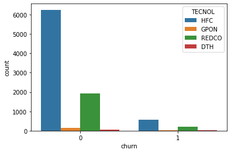

```python
sns.countplot(x='churn',hue='TECNOL',data=churn_df)
```

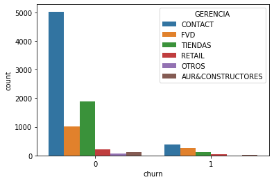

```python
sns.countplot(x='churn',hue='GERENCIA',data=churn_df)
```

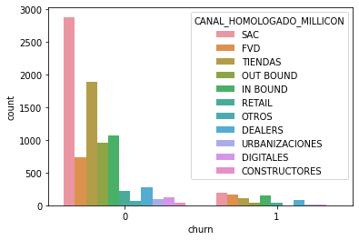

```python
sns.countplot(x='churn',hue='CANAL_HOMOLOGADO_MILLICON',data=churn_df)
```

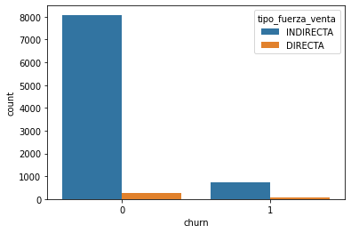

```python
sns.countplot(x='churn',hue='tipo_fuerza_venta',data=churn_df)
```

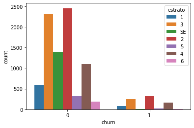

```python
sns.countplot(x='churn',hue='estrato',data=churn_df)
```

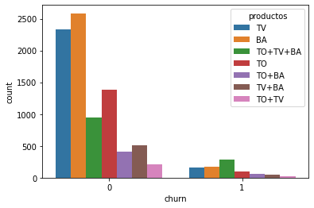

```python
sns.countplot(x='churn',hue='productos',data=churn_df)
```

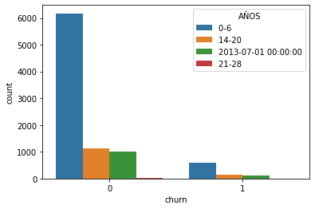

```python
sns.countplot(x='churn',hue='AÑOS',data=churn_df)
```

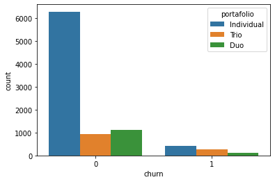

```python
sns.countplot(x='churn',hue='portafolio',data=churn_df)
```

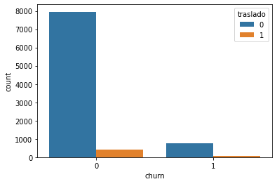

```python
sns.countplot(x='churn',hue='traslado',data=churn_df)
```

```python
# Conteos de clientes por estrategia, según decision tree

churn_df[(churn_df['estrato']==SE) & (churn_df['AÑOS']=='0-6') & (churn_df['GERENCIA']=='FVD')& (churn_df['TECNOL']=='HFC')& (churn_df['productos']=='TV')].count()
```

```python
churn_df[(churn_df['estrato']==4) & (churn_df['REGIONAL']=='NOROCCIDENTE') & (churn_df['portafolio']=='Trio')& (churn_df['traslado']==1)].count()
```

```python
churn_df[(churn_df['pedidos_peticiones']==1)&(churn_df['productos']=='TO')&(churn_df['estrato']==3)&(churn_df['REGIONAL']=='SUR')&(churn_df['productos']=='TV')].count()
```

```python
churn_df['cliente_id']=churn_df.cliente_id.astype(int)
```

```python
## Calidad de los datos: total de datos faltantes ##

print(churn_df.isnull().sum())
```

```
REGIONAL                     0
TECNOL                       0
GERENCIA                     0
CANAL_HOMOLOGADO_MILLICON    0
tipo_fuerza_venta            0
estrato                      0
productos                    0
AÑOS                         0
portafolio                   0
asesoria_factura             0
pedidos_peticiones           0
reagendamiento               0
asesoria_servicios           0
retencion                    0
Otras                        0
quejas_fraude                0
traslado                     0
Incumplimiento_pago          0
cliente_id                   0
churn                        0
dtype: int64
```

No hay datos faltantes

```python
churn_df.groupby("churn").agg('count')
```

| churn | REGIONAL | TECNOL | GERENCIA | CANAL_HOMOLOGADO_MILLICON | tipo_fuerza_venta | estrato | productos | AÑOS | portafolio | asesoria_factura | pedidos_peticiones | reagendamiento | asesoria_servicios | retencion | Otras | quejas_fraude | traslado | Incumplimiento_pago | cliente_id |
| --- | --- | --- | --- | --- | --- | --- | --- | --- | --- | --- | --- | --- | --- | --- | --- | --- | --- | --- | --- |
| 0 | 8354 | 8354 | 8354 | 8354 | 8354 | 8354 | 8354 | 8354 | 8354 | 8354 | 8354 | 8354 | 8354 | 8354 | 8354 | 8354 | 8354 | 8354 | 8354 |
| 1 | 828 | 828 | 828 | 828 | 828 | 828 | 828 | 828 | 828 | 828 | 828 | 828 | 828 | 828 | 828 | 828 | 828 | 828 | 828 |

```python
828/8354 # % de churn
```

```
0.09911419679195595
```

Hay 8354 registros de churn=0 y 828 registros de churn=1, las clases están desbalanceadas, ya que solo el 10% de los datos tiene información sobre personas que registraron incumplimiento de pago, con lo cual predecir sobre este dataset conllevaría a imprecisiones.

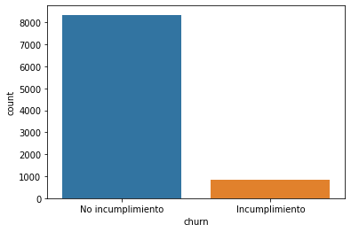

```python
# visualize the target variable
g = sns.countplot(churn_df['churn'])
g.set_xticklabels(['No incumplimiento','Incumplimiento'])
plt.show()
```

```python
# Variables explicativas y variable respuesta
# Variable respuesta: La variable churn en un vector aparte:
y = np.asarray(churn_df['churn'])
X = churn_df[['REGIONAL', 'TECNOL', 'GERENCIA', 'CANAL_HOMOLOGADO_MILLICON','tipo_fuerza_venta','estrato','productos','AÑOS','portafolio','asesoria_factura','pedidos_peticiones','reagendamiento','asesoria_servicios','retencion','Otras','quejas_fraude','traslado']]
ids  = churn_df['cliente_id']
```

Las variables de tipo categórico se vuelven de tipo dummy con one hot encoding, que no tiene en cuenta ningún ordenamiento entre las categorías.

```python
X_with_dummy_features = pd.get_dummies(X,drop_first=True)
y_with_dummy_features = pd.get_dummies(y,drop_first=True)
```

```python
X_with_dummy_features.head()
```

|  | REGIONAL_COSTA | REGIONAL_EJE CAFETERO | REGIONAL_NOROCCIDENTE | REGIONAL_ORIENTE | REGIONAL_SUR | TECNOL_GPON | TECNOL_HFC | TECNOL_REDCO | GERENCIA_CONTACT | GERENCIA_FVD | GERENCIA_OTROS | GERENCIA_RETAIL | GERENCIA_TIENDAS | CANAL_HOMOLOGADO_MILLICON_DEALERS | CANAL_HOMOLOGADO_MILLICON_DIGITALES | CANAL_HOMOLOGADO_MILLICON_FVD | CANAL_HOMOLOGADO_MILLICON_IN BOUND | CANAL_HOMOLOGADO_MILLICON_OTROS | CANAL_HOMOLOGADO_MILLICON_OUT BOUND | CANAL_HOMOLOGADO_MILLICON_RETAIL | CANAL_HOMOLOGADO_MILLICON_SAC | CANAL_HOMOLOGADO_MILLICON_TIENDAS | CANAL_HOMOLOGADO_MILLICON_URBANIZACIONES | tipo_fuerza_venta_INDIRECTA | estrato_2 | estrato_3 | estrato_4 | estrato_5 | estrato_6 | … |
| --- | --- | --- | --- | --- | --- | --- | --- | --- | --- | --- | --- | --- | --- | --- | --- | --- | --- | --- | --- | --- | --- | --- | --- | --- | --- | --- | --- | --- | --- | --- |
| 2 | 0 | 0 | 1 | 0 | 0 | 0 | 1 | 0 | 1 | 0 | 0 | 0 | 0 | 0 | 0 | 0 | 0 | 0 | 0 | 0 | 1 | 0 | 0 | 1 | 0 | 0 | 0 | 0 | 0 | … |
| 8 | 0 | 1 | 0 | 0 | 0 | 0 | 1 | 0 | 0 | 1 | 0 | 0 | 0 | 0 | 0 | 1 | 0 | 0 | 0 | 0 | 0 | 0 | 0 | 1 | 0 | 1 | 0 | 0 | 0 | … |
| 12 | 0 | 1 | 0 | 0 | 0 | 0 | 1 | 0 | 0 | 0 | 0 | 0 | 1 | 0 | 0 | 0 | 0 | 0 | 0 | 0 | 0 | 1 | 0 | 1 | 0 | 0 | 0 | 0 | 0 | … |
| 13 | 0 | 1 | 0 | 0 | 0 | 0 | 1 | 0 | 0 | 0 | 0 | 0 | 1 | 0 | 0 | 0 | 0 | 0 | 0 | 0 | 0 | 1 | 0 | 1 | 0 | 0 | 0 | 0 | 0 | … |
| 14 | 0 | 0 | 0 | 1 | 0 | 1 | 0 | 0 | 0 | 0 | 0 | 0 | 1 | 0 | 0 | 0 | 0 | 0 | 0 | 0 | 0 | 1 | 0 | 1 | 0 | 0 | 0 | 0 | 0 | … |

## Se divide en datasets de entrenamiento y validación

```python
xtrain, xtest, ytrain, ytest , id_train, id_test = train_test_split \
                (X_with_dummy_features, y_with_dummy_features,ids,test_size=0.3, \
                stratify=y_with_dummy_features,random_state=1000)
print ("No. of True Cases in training data set for" , ytrain.values.ravel().sum())
print ("No. of True Cases in testing data set for",ytest.values.ravel().sum())

print ("Ratio of True Cases in training data set: " , round(ytrain.values.ravel().sum()/len(ytrain.values.ravel()),2))
print ("Ratio of True Cases in testing data set: ", round(ytest.values.ravel().sum()/len(ytest.values.ravel()),2))
```

```
No. of True Cases in training data set for 580
No. of True Cases in testing data set for 248
Ratio of True Cases in training data set:  0.09
Ratio of True Cases in testing data set:  0.09
```

El número de churn en el conjunto de entrenamiento es de 580, es decir, el 9%

xtest tiene 2755 registros

# Entrenamiento del modelo y evaluación de diferentes clasificadores

## Regresión logística: Logit

- Beneficios: Fácil de interpretar
- Limitaciones: no se comporta bien con las relaciones de tipo no lineal, es sensible a outliers, funciona mejor con variables numéricas.
- Permite calcular la probabilidad de que un cliente no pague la primera factura en este dataset.

```python
#initialize model performance comparison dataframe
eval_results_compare = pd.DataFrame()
```

```python
model_name = 'Logistic Regression'
logreg = LogisticRegression()
trained_model_lr = logreg.fit(xtrain, ytrain.values.ravel())
```

```python
print ("Trained model :: ", trained_model_lr)
```

```
Trained model ::  LogisticRegression(C=1.0, class_weight=None, dual=False, fit_intercept=True,
                   intercept_scaling=1, l1_ratio=None, max_iter=100,
                   multi_class='auto', n_jobs=None, penalty='l2',
                   random_state=None, solver='lbfgs', tol=0.0001, verbose=0,
                   warm_start=False)
```

Se calculan las probabilidades de predicción en el set de prueba y de entrenamiento mediante la función predict

```python
prob_test  = trained_model_lr.predict_proba(xtest)
prob_train = trained_model_lr.predict_proba(xtrain)

#Probability Threshold = 0.5 (default)
pred_test  = trained_model_lr.predict(xtest)
pred_train = trained_model_lr.predict(xtrain)
```

### AUC: Área bajo la curva, métrica que calcula el performance general de un modelo de clasificación basado en el área bajo la curva de ROC

```python
#Calculate AUC
auc_score = roc_auc_score(ytest, prob_test[:,1])
print ("\n\nModel ROC-AUC score for validation sample: %.3f" \
                                      % auc_score)

#Calculate train and test accuracy
train_acc = accuracy_score(ytrain.values.ravel(), pred_train)
test_acc  = accuracy_score(ytest.values.ravel(), pred_test)
print ("\nTrain Accuracy :: ", train_acc)
print ("\nTest Accuracy :: ", test_acc)
```

```
Model ROC-AUC score for validation sample: 0.770

Train Accuracy ::  0.9127119962657538

Test Accuracy ::  0.9078039927404719
```

En este caso la precisión es del 91% aproximadamente lo que es muy bueno

```python
## Matriz de Confusion

from sklearn.metrics import classification_report, confusion_matrix
import itertools
def plot_confusion_matrix(cm, classes,
                         normalize=False,
                         title='Confusion matrix',
                         cmap=plt.cm.Blues):

  """
    This function prints and plots the confusion matrix.
    Normalization can be applied by setting `normalize=True`.
    """
  if normalize:
    cm = cm.astype('float') / cm.sum(axis=1)[:, np.newaxis]
    print("Normalized confusion matrix")
  else:
    print('Confusion matrix, without normalization')

    print(cm)

    plt.imshow(cm, interpolation='nearest', cmap=cmap)
    plt.title(title)
    plt.colorbar()
    tick_marks = np.arange(len(classes))
    plt.xticks(tick_marks, classes, rotation=45)
    plt.yticks(tick_marks, classes)

    fmt = '.2f' if normalize else 'd'
    thresh = cm.max() / 2.
    for i, j in itertools.product(range(cm.shape[0]), range(cm.shape[1])):
      plt.text(j, i, format(cm[i, j], fmt),
              horizontalalignment="center",
              color="white" if cm[i, j] > thresh else "black")

    plt.tight_layout()
    plt.ylabel('True label')
    plt.xlabel('Predicted label')
  print(confusion_matrix(ytest, pred_test, labels=[1,0]))
```

```
Confusion matrix, without normalization
[[  17  231]
 [  23 2484]]
[[  17  231]
 [  23 2484]]
```

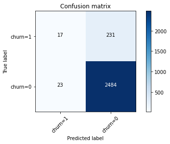

```python
# Calcular la matriz de confusion
cnf_matrix = confusion_matrix(ytest.values.ravel(), pred_test, labels=[1,0])
np.set_printoptions(precision=2)

# Graficar la matriz de confusion no normalizada
plt.figure()
plot_confusion_matrix(cnf_matrix, classes=['churn=1', 'churn=0'], normalize= False, title='Confusion matrix')
```

- Recall: proporción de positivos actuales (TP+FN) que fueron identificados correctamente (TP)-->TP/(TP+FN)
- Precision: prop. de positivos identificados (TP+FP) que fueron correctos (TP)-->TP/(TP+FP)
- F1 score: métrica qeu combina recall y precision usando la media armónica.
- El promedio ponderado se basa en el número de instancias de cada clase, es útil en el caso desbalanceado, pero el impacto de la clase menos frecuente se omite.
- La curva precision-recall con la curva ROC puede ser usada para seleccionar un umbral de corte óptimo basado en el clasificador predictivo que sirva para el objetivo del negocio.

```python
#Calculate classification model evaluation metrics like precision, recall, f1 score
report = classification_report(ytest, pred_test)
precision,recall,fscore,support = precision_recall_fscore_support(ytest,pred_test,average='weighted')
print("\n Classification report (weighted average across classes) ::\n", classification_report(ytest, pred_test))
```

```
 Classification report (weighted average across classes) ::
               precision    recall  f1-score   support

           0       0.91      0.99      0.95      2507
           1       0.42      0.07      0.12       248

    accuracy                           0.91      2755
   macro avg       0.67      0.53      0.53      2755
weighted avg       0.87      0.91      0.88      2755
```

El promedio ponderado está sesgado hacia la clase más frecuente, se usará la precision, el recall y el score f1 de la clase positiva más pequeña para futuras evaluaciones del modelo.

La probabilidad del umbral es de 0.5 por default.

# Se calcula el umbral o punto de corte óptimo, según la siguiente gráfica

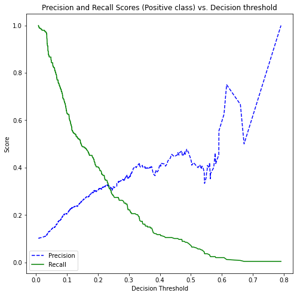

```python
#Obtain the precision and recall for the corresponding variations in threshold
p, r, thresholds = precision_recall_curve(ytest, prob_test[:,1])

def plot_precision_recall_vs_threshold(precisions, recalls, thresholds):
    """
    Modified from:
    Hands-On Machine learning with Scikit-Learn
    """

    plt.figure(figsize=(8, 8))
    plt.title("Precision and Recall Scores (Positive class) vs. Decision threshold")
    plt.plot(thresholds, precisions[:-1], "b--", label="Precision")
    plt.plot(thresholds, recalls[:-1], "g-", label="Recall")
    plt.ylabel("Score")
    plt.xlabel("Decision Threshold")
    plt.legend(loc='best')

plot_precision_recall_vs_threshold(p, r, thresholds)
plt.show()
```

Se observa que un umbral más bajo que 0.25 se requiere para obtener un valor más alto de recall.

# Naive Bayes

- Beneficios: simple y rápido, funciona bien con muestras pequeñas.
- Limitaciones: falla al estimar ocurrencias raras, puede que las probabilidades estimadas no sean confiables.

```python
model_name        = 'Gaussian Naive Bayes'
gnb               = GaussianNB()
trained_model_gnb = gnb.fit(xtrain, ytrain.values.ravel())
```

```python
prob_test  = trained_model_gnb.predict_proba(xtest)
prob_train = trained_model_gnb.predict_proba(xtrain)

#Probability Threshold = 0.5 (default)
pred_test  = trained_model_gnb.predict(xtest)
pred_train = trained_model_gnb.predict(xtrain)

#Calculate AUC
auc_score = roc_auc_score(ytest, prob_test[:,1])
print ("\n\nModel ROC-AUC score for validation sample: %.3f" \
                                      % auc_score)

#Calculate train and test accuracy
train_acc = accuracy_score(ytrain.values.ravel(), pred_train)
test_acc  = accuracy_score(ytest.values.ravel(), pred_test)
print ("\nTrain Accuracy :: ", train_acc)
print ("\nTest Accuracy :: ", test_acc)
```

```
Model ROC-AUC score for validation sample: 0.738

Train Accuracy ::  0.7676987708106426

Test Accuracy ::  0.7535390199637023
```

```python
# I've got my predictions now

#y_hats  = trained_model_gnb.predict(xtest)
y_hats  = pd.DataFrame(prob_test)
proba = y_hats[1]
proba = pd.DataFrame(proba)
proba
```

|  | 1 |
| --- | --- |
| 0 | 1.853442e-27 |
| 1 | 2.513857e-03 |
| 2 | 9.994890e-01 |
| 3 | 7.259130e-26 |
| 4 | 3.981037e-02 |
| ... | ... |
| 2750 | 1.000000e+00 |
| 2751 | 1.426681e-01 |
| 2752 | 1.967733e-01 |
| 2753 | 9.677496e-01 |
| 2754 | 9.551857e-02 |

2755 rows × 1 columns

```python
df_out = pd.merge(xtest,proba ,how = 'left',left_index = True, right_index = True)
df_out
```

|  | REGIONAL_COSTA | REGIONAL_EJE CAFETERO | REGIONAL_NOROCCIDENTE | REGIONAL_ORIENTE | REGIONAL_SUR | TECNOL_GPON | TECNOL_HFC | TECNOL_REDCO | GERENCIA_CONTACT | GERENCIA_FVD | GERENCIA_OTROS | GERENCIA_RETAIL | GERENCIA_TIENDAS | CANAL_HOMOLOGADO_MILLICON_DEALERS | CANAL_HOMOLOGADO_MILLICON_DIGITALES | CANAL_HOMOLOGADO_MILLICON_FVD | CANAL_HOMOLOGADO_MILLICON_IN BOUND | CANAL_HOMOLOGADO_MILLICON_OTROS | CANAL_HOMOLOGADO_MILLICON_OUT BOUND | CANAL_HOMOLOGADO_MILLICON_RETAIL | CANAL_HOMOLOGADO_MILLICON_SAC | CANAL_HOMOLOGADO_MILLICON_TIENDAS | CANAL_HOMOLOGADO_MILLICON_URBANIZACIONES | tipo_fuerza_venta_INDIRECTA | estrato_2 | estrato_3 | estrato_4 | estrato_5 | estrato_6 | … |
| --- | --- | --- | --- | --- | --- | --- | --- | --- | --- | --- | --- | --- | --- | --- | --- | --- | --- | --- | --- | --- | --- | --- | --- | --- | --- | --- | --- | --- | --- | --- |
| 9498 | 0 | 1 | 0 | 0 | 0 | 0 | 1 | 0 | 1 | 0 | 0 | 0 | 0 | 0 | 0 | 0 | 1 | 0 | 0 | 0 | 0 | 0 | 0 | 1 | 0 | 0 | 0 | 0 | 0 | … |
| 15162 | 0 | 0 | 1 | 0 | 0 | 0 | 1 | 0 | 1 | 0 | 0 | 0 | 0 | 0 | 0 | 0 | 0 | 0 | 1 | 0 | 0 | 0 | 0 | 1 | 1 | 0 | 0 | 0 | 0 | … |
| 12505 | 0 | 0 | 1 | 0 | 0 | 0 | 1 | 0 | 1 | 0 | 0 | 0 | 0 | 0 | 0 | 0 | 1 | 0 | 0 | 0 | 0 | 0 | 0 | 1 | 0 | 0 | 1 | 0 | 0 | … |
| 19697 | 0 | 0 | 1 | 0 | 0 | 0 | 0 | 1 | 1 | 0 | 0 | 0 | 0 | 0 | 0 | 0 | 0 | 0 | 0 | 0 | 1 | 0 | 0 | 1 | 0 | 0 | 0 | 0 | 0 | … |
| 14822 | 0 | 0 | 1 | 0 | 0 | 0 | 1 | 0 | 1 | 0 | 0 | 0 | 0 | 0 | 0 | 0 | 0 | 0 | 0 | 0 | 1 | 0 | 0 | 1 | 1 | 0 | 0 | 0 | 0 | … |
| ... | ... | ... | ... | ... | ... | ... | ... | ... | ... | ... | ... | ... | ... | ... | ... | ... | ... | ... | ... | ... | ... | ... | ... | ... | ... | ... | ... | ... | ... | … |
| 6121 | 0 | 0 | 1 | 0 | 0 | 0 | 1 | 0 | 0 | 1 | 0 | 0 | 0 | 1 | 0 | 0 | 0 | 0 | 0 | 0 | 0 | 0 | 0 | 0 | 1 | 0 | 0 | 0 | 0 | … |
| 19628 | 0 | 0 | 1 | 0 | 0 | 0 | 0 | 1 | 1 | 0 | 0 | 0 | 0 | 0 | 0 | 0 | 0 | 0 | 0 | 0 | 1 | 0 | 0 | 1 | 0 | 0 | 1 | 0 | 0 | … |
| 19436 | 0 | 0 | 1 | 0 | 0 | 0 | 1 | 0 | 1 | 0 | 0 | 0 | 0 | 0 | 0 | 0 | 1 | 0 | 0 | 0 | 0 | 0 | 0 | 1 | 0 | 1 | 0 | 0 | 0 | … |
| 16379 | 0 | 0 | 1 | 0 | 0 | 0 | 0 | 1 | 0 | 0 | 0 | 0 | 1 | 0 | 0 | 0 | 0 | 0 | 0 | 0 | 0 | 1 | 0 | 1 | 0 | 1 | 0 | 0 | 0 | … |
| 7445 | 0 | 0 | 1 | 0 | 0 | 0 | 1 | 0 | 1 | 0 | 0 | 0 | 0 | 0 | 0 | 0 | 0 | 0 | 0 | 0 | 1 | 0 | 0 | 1 | 0 | 0 | 0 | 0 | 0 | … |

2755 rows × 50 columns

En este caso la precisión es del 75% aproximadamente lo cual no es tan bueno

```python
#Calculate classification model evaluation metrics like precision, recall, f1 score
report = classification_report(ytest, pred_test)
precision,recall,fscore,support = precision_recall_fscore_support(ytest,pred_test,average='weighted')
print("\n Classification report (weighted average across classes) ::\n", classification_report(ytest, pred_test))
```

```
 Classification report (weighted average across classes) ::
               precision    recall  f1-score   support

           0       0.95      0.77      0.85      2507
           1       0.21      0.62      0.31       248

    accuracy                           0.75      2755
   macro avg       0.58      0.69      0.58      2755
weighted avg       0.89      0.75      0.80      2755
```

# Árbol de decisión

- Beneficios: Fácil de entender y visualizar, funciona bien con datos numéricos y categóricos.
- Limitaciones: Es común el sobreajuste, el proceso de "podado" se vuelve esencial.

```python
model_name = 'Decision Tree'
dt=DecisionTreeClassifier()
trained_model_dt = dt.fit(xtrain,ytrain)
```

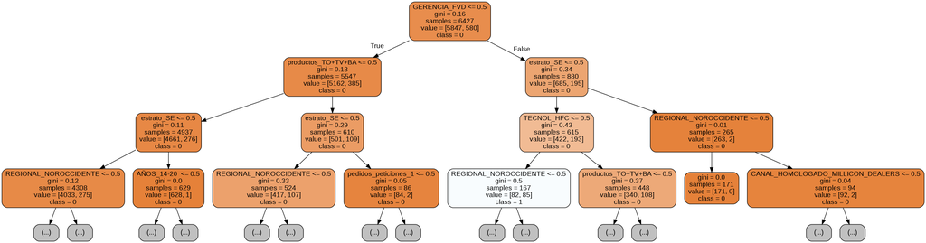

```python
dot_data = StringIO()

export_graphviz(trained_model_dt, out_file=dot_data,
                feature_names = xtrain.columns,
                max_depth = 3,
                class_names = ['0','1'],
                rounded = True, proportion = False,
                precision = 2, filled = True)

graph = pydotplus.graph_from_dot_data(dot_data.getvalue())
Image(graph.create_png())
```

```python
prob_test  = trained_model_dt.predict_proba(xtest)
prob_train = trained_model_dt.predict_proba(xtrain)

#Probability Threshold = 0.5 (default)
pred_test  = trained_model_dt.predict(xtest)
pred_train = trained_model_dt.predict(xtrain)

#Calculate AUC
auc_score = roc_auc_score(ytest, prob_test[:,1])
print ("\n\nModel ROC-AUC score for validation sample: %.3f" \
                                      % auc_score)

#Calculate train and test accuracy
train_acc = accuracy_score(ytrain.values.ravel(), pred_train)
test_acc  = accuracy_score(ytest.values.ravel(), pred_test)
print ("\nTrain Accuracy :: ", train_acc)
print ("\nTest Accuracy :: ", test_acc)
```

```
Model ROC-AUC score for validation sample: 0.649

Train Accuracy ::  0.9516103936517816

Test Accuracy ::  0.8889292196007259
```

```python
#Calculate classification model evaluation metrics like precision, recall, f1 score
report = classification_report(ytest, pred_test)
precision,recall,fscore,support = precision_recall_fscore_support(ytest,pred_test,average='weighted')
print("\n Classification report (weighted average across classes) ::\n", classification_report(ytest, pred_test))
```

```
 Classification report (weighted average across classes) ::
               precision    recall  f1-score   support

           0       0.93      0.96      0.94      2507
           1       0.33      0.22      0.26       248

    accuracy                           0.89      2755
   macro avg       0.63      0.59      0.60      2755
weighted avg       0.87      0.89      0.88      2755
```

# Random Forest

- Beneficios: Reduce la varianza y previene el sobreajuste, es robusto y preciso.
- Limitaciones: Un gran número de árboles puede disminuir el performance, es menos interpretable

```python
# Create random forest classifier model to predict chrun
model_name = 'Random Forest'
clf = RandomForestClassifier()
trained_model_rf = clf.fit(xtrain, ytrain.values.ravel())
```

```python
prob_test  = trained_model_rf.predict_proba(xtest)
prob_train = trained_model_rf.predict_proba(xtrain)

#Probability Threshold = 0.5 (default)
pred_test  = trained_model_rf.predict(xtest)
pred_train = trained_model_rf.predict(xtrain)

#Calculate AUC
auc_score = roc_auc_score(ytest, prob_test[:,1])
print ("\n\nModel ROC-AUC score for validation sample: %.3f" \
                                      % auc_score)

#Calculate train and test accuracy
train_acc = accuracy_score(ytrain.values.ravel(), pred_train)
test_acc  = accuracy_score(ytest.values.ravel(), pred_test)
print ("\nTrain Accuracy :: ", train_acc)
print ("\nTest Accuracy :: ", test_acc)
```

```
Model ROC-AUC score for validation sample: 0.711

Train Accuracy ::  0.9516103936517816

Test Accuracy ::  0.8998185117967332
```

```python
#Calculate classification model evaluation metrics like precision, recall, f1 score
report = classification_report(ytest, pred_test)
precision,recall,fscore,support = precision_recall_fscore_support(ytest,pred_test,average='weighted')
print("\n Classification report (weighted average across classes) ::\n", classification_report(ytest, pred_test))
```

```
 Classification report (weighted average across classes) ::
               precision    recall  f1-score   support

           0       0.92      0.97      0.95      2507
           1       0.39      0.19      0.26       248

    accuracy                           0.90      2755
   macro avg       0.66      0.58      0.60      2755
weighted avg       0.88      0.90      0.88      2755
```